# Analysis of Titanic Data

On April 15, 1912, the Titanic sank after colliding with an iceberg, killing 1502 out of 2224 passengers and crew.This data set contains demographics and passenger information from 891 of the 2224 passengers and crew on board the Titanic.

Investigation of which factors made people more likely to survive in Titanic disaster is aimed with this analysis.

**Questions:**

1. Were "age of passengers" an important factor for rescue?
2. Did "ticket fare and Class" have effect on the survival chance?
3. Did "women and children passengers" have more chance to survive from the disaster than "adult men"?
4. Did family size on board help to keep alive?

### Data Dictionary

| Variable | Definition | Key |
| --- | --- | --- |
| survival | Survival | 0 = No, 1 = Yes |
| pclass | Ticket class | 1 = 1st, 2 = 2nd, 3 = 3rd |
| sex | Sex |  |
| age | Age in years |  |
| sibsp | # of siblings / spouses aboard the Titanic |  |
| parch | # of parents / children aboard the Titanic |  |
| ticket | Ticket number |  |
| fare | Passenger fare |  |
| cabin | Cabin number |  |
| embarked | Port of Embarkation | C = Cherbourg, Q = Queenstown, S = Southampton |

#### Variable Notes

pclass: A proxy for socio-economic status (SES)

- 1st = Upper
- 2nd = Middle
- 3rd = Lower

age: Age is fractional if less than 1. If the age is estimated, is it in the form of xx.5

sibsp: The dataset defines family relations in this way...

- Sibling = brother, sister, stepbrother, stepsister
- Spouse = husband, wife (mistresses and fiancés were ignored)

parch: The dataset defines family relations in this way...

- Parent = mother, father
- Child = daughter, son, stepdaughter, stepson
- Some children travelled only with a nanny, therefore parch=0 for them.

We can start with importing of functional libraries and loading dataset as dataframe:

```python
import numpy as np
import pandas as pd
import matplotlib.pyplot as plt
%matplotlib inline
import seaborn as sns

data = pd.read_csv("./titanic-data.csv")
```

We can look through first 5 rows with head() function and get insight on data:

```python
data.head()
```

|  | PassengerId | Survived | Pclass | Name | Sex | Age | SibSp | Parch | Ticket | Fare | Cabin | Embarked |
| --- | --- | --- | --- | --- | --- | --- | --- | --- | --- | --- | --- | --- |
| 0 | 1 | 0 | 3 | Braund, Mr. Owen Harris | male | 22.0 | 1 | 0 | A/5 21171 | 7.2500 | NaN | S |
| 1 | 2 | 1 | 1 | Cumings, Mrs. John Bradley (Florence Briggs Th... | female | 38.0 | 1 | 0 | PC 17599 | 71.2833 | C85 | C |
| 2 | 3 | 1 | 3 | Heikkinen, Miss. Laina | female | 26.0 | 0 | 0 | STON/O2. 3101282 | 7.9250 | NaN | S |
| 3 | 4 | 1 | 1 | Futrelle, Mrs. Jacques Heath (Lily May Peel) | female | 35.0 | 1 | 0 | 113803 | 53.1000 | C123 | S |
| 4 | 5 | 0 | 3 | Allen, Mr. William Henry | male | 35.0 | 0 | 0 | 373450 | 8.0500 | NaN | S |

We can get information of number of non-null entries in columns and type of variables:

```python
data.info()
```

```
<class 'pandas.core.frame.DataFrame'>
RangeIndex: 891 entries, 0 to 890
Data columns (total 12 columns):
PassengerId    891 non-null int64
Survived       891 non-null int64
Pclass         891 non-null int64
Name           891 non-null object
Sex            891 non-null object
Age            714 non-null float64
SibSp          891 non-null int64
Parch          891 non-null int64
Ticket         891 non-null object
Fare           891 non-null float64
Cabin          204 non-null object
Embarked       889 non-null object
dtypes: float64(2), int64(5), object(5)
memory usage: 83.6+ KB
```

We can look at main properties of numeric columns by "describe":

```python
data.describe()
```

|  | PassengerId | Survived | Pclass | Age | SibSp | Parch | Fare |
| --- | --- | --- | --- | --- | --- | --- | --- |
| count | 891.000000 | 891.000000 | 891.000000 | 714.000000 | 891.000000 | 891.000000 | 891.000000 |
| mean | 446.000000 | 0.383838 | 2.308642 | 29.699118 | 0.523008 | 0.381594 | 32.204208 |
| std | 257.353842 | 0.486592 | 0.836071 | 14.526497 | 1.102743 | 0.806057 | 49.693429 |
| min | 1.000000 | 0.000000 | 1.000000 | 0.420000 | 0.000000 | 0.000000 | 0.000000 |
| 25% | 223.500000 | 0.000000 | 2.000000 | 20.125000 | 0.000000 | 0.000000 | 7.910400 |
| 50% | 446.000000 | 0.000000 | 3.000000 | 28.000000 | 0.000000 | 0.000000 | 14.454200 |
| 75% | 668.500000 | 1.000000 | 3.000000 | 38.000000 | 1.000000 | 0.000000 | 31.000000 |
| max | 891.000000 | 1.000000 | 3.000000 | 80.000000 | 8.000000 | 6.000000 | 512.329200 |

##### These are summary of findings :

- There are 891 passengers.
- 38.38 % of people was survived.
- More than half of the passengers were from 3rd Class.
- Average age on board was 29.699.
- The oldest people was 80 years old, the youngest was nearly 5 months old.
- Less than 25 % of people has a parent or child.
- Average fare was 32.20 when the most expensive fare was 512.33.

We detected that there are 177 missing values in Age column. We can use .fillna to assign values instead of these missing ones. However this can mislead us for that dataset. So they will be just removed but size of our dataset get smaller.

Also large amount of cabin values, are missing, just 204 values exists. So we can neglect it and loose some information. We can also create new column with cabin values exist or not.

Embarked column has 2 missing values and we can neglect it.

We can use this new cleaned dataset for investigation related with age:

```python
clean_data=data.drop(['Cabin'], axis = 1) #Delete "Cabin" column
clean_data = clean_data.dropna(axis=0, how='any') #Delete all rows which any column value is NAN or Null.
clean_data.info()
```

```
<class 'pandas.core.frame.DataFrame'>
Int64Index: 712 entries, 0 to 890
Data columns (total 11 columns):
PassengerId    712 non-null int64
Survived       712 non-null int64
Pclass         712 non-null int64
Name           712 non-null object
Sex            712 non-null object
Age            712 non-null float64
SibSp          712 non-null int64
Parch          712 non-null int64
Ticket         712 non-null object
Fare           712 non-null float64
Embarked       712 non-null object
dtypes: float64(2), int64(5), object(4)
memory usage: 66.8+ KB
```

Let's create histogram of age values. Each bar is indivual age value due to bins equal to 80.

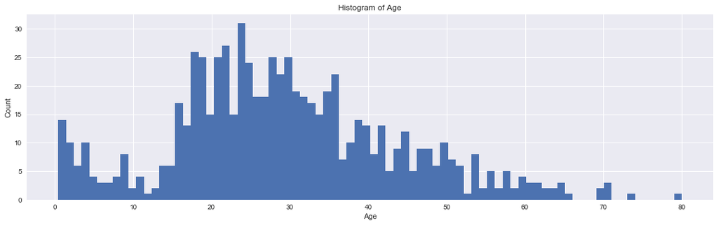

```python
clean_data.hist(column='Age',figsize=(18,5), bins=80)
plt.xlabel("Age")
plt.ylabel("Count")
plt.title("Histogram of Age");
```

Most of the passengers are between 18 and 36 years old. We can also investigate age statistics according to survival.

```python
clean_data.groupby('Survived').Age.describe().T
```

| Survived | 0 | 1 |
| --- | --- | --- |
| count | 424.000000 | 288.000000 |
| mean | 30.626179 | 28.193299 |
| std | 14.172110 | 14.859146 |
| min | 1.000000 | 0.420000 |
| 25% | 21.000000 | 19.000000 |
| 50% | 28.000000 | 28.000000 |
| 75% | 39.000000 | 36.000000 |
| max | 74.000000 | 80.000000 |

We can use Mann Whitney U Test to determine this two groups are statiscally different from each according to age distribution.

Null hypothesis is that they are same. If p-value is found less than 0.05; we can change our null to alternative one which states they are statistically different.

```python
survived_age = clean_data[clean_data['Survived']==1].Age
non_survived_age = clean_data[clean_data['Survived']==0].Age
```

```python
from scipy import stats
stats.mannwhitneyu(survived_age,non_survived_age, alternative="two-sided") # alternatives: 'less', 'two-sided','greater'
```

```
MannwhitneyuResult(statistic=56961.0, pvalue=0.12837188836279587)
```

So null hypothesis is preserved and there is no statiscally difference between survived and non-survived people according to age.

We can also visualize age distribution:

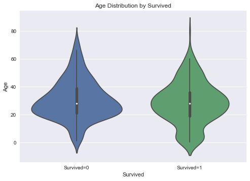

```python
age_violin = sns.violinplot(data = data, x = 'Survived', y = 'Age')
age_violin.set(title = 'Age Distribution by Survived',
        xlabel = 'Survived',
        ylabel = 'Age',
        xticklabels = ['Survived=0', 'Survived=1']);
```

**Answer for Question-1:**

Age is not important factor solely. Maybe it becomes important by interaction with other attributes.

Let's create histogram of fare values. Each bin is incremented with 10$ value.

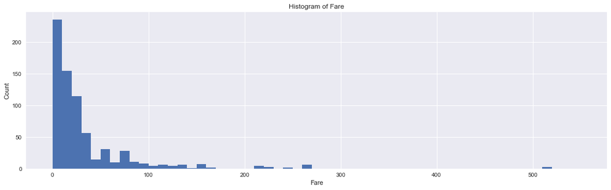

```python
clean_data.hist(column='Fare',figsize=(18,5), bins=55, range=(0,550))
plt.xlabel("Fare")
plt.ylabel("Count")
plt.title("Histogram of Fare");
```

```python
clean_data.Fare.describe()
```

```
count    712.000000
mean      34.567251
std       52.938648
min        0.000000
25%        8.050000
50%       15.645850
75%       33.000000
max      512.329200
Name: Fare, dtype: float64
```

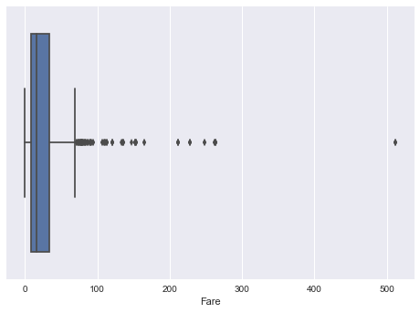

```python
ax = sns.boxplot(x="Fare", data=clean_data)
```

Most of the passengers paid for tickets less than 30$.There are some outliers in fare attribute. We can clasify tickets as normal(<=30), expensive (30-80) and outlier(>=80); and then investigate survival rates of passengers who bought those tickets:

```python
def fare_status(Fare):
    if Fare  > 80:
        return 'Outlier'
    elif Fare  > 30:
        return 'Expensive'
    else:
        return 'Normal'
```

```python
clean_data['Fare_Status'] = clean_data['Fare'].apply(fare_status)
```

```python
clean_data.head()
```

|  | PassengerId | Survived | Pclass | Name | Sex | Age | SibSp | Parch | Ticket | Fare | Embarked | Fare_Status |
| --- | --- | --- | --- | --- | --- | --- | --- | --- | --- | --- | --- | --- |
| 0 | 1 | 0 | 3 | Braund, Mr. Owen Harris | male | 22.0 | 1 | 0 | A/5 21171 | 7.2500 | S | Normal |
| 1 | 2 | 1 | 1 | Cumings, Mrs. John Bradley (Florence Briggs Th... | female | 38.0 | 1 | 0 | PC 17599 | 71.2833 | C | Expensive |
| 2 | 3 | 1 | 3 | Heikkinen, Miss. Laina | female | 26.0 | 0 | 0 | STON/O2. 3101282 | 7.9250 | S | Normal |
| 3 | 4 | 1 | 1 | Futrelle, Mrs. Jacques Heath (Lily May Peel) | female | 35.0 | 1 | 0 | 113803 | 53.1000 | S | Expensive |
| 4 | 5 | 0 | 3 | Allen, Mr. William Henry | male | 35.0 | 0 | 0 | 373450 | 8.0500 | S | Normal |

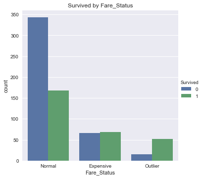

```python
sns.factorplot('Fare_Status', hue = "Survived", size = 5, data = clean_data, kind = 'count')
plt.title('Survived by Fare_Status');
```

```python
clean_data.groupby('Fare_Status')["Survived"].describe().T
```

| Fare_Status | Expensive | Normal | Outlier |
| --- | --- | --- | --- |
| count | 134.000000 | 511.000000 | 67.000000 |
| mean | 0.507463 | 0.328767 | 0.776119 |
| std | 0.501820 | 0.470225 | 0.419989 |
| min | 0.000000 | 0.000000 | 0.000000 |
| 25% | 0.000000 | 0.000000 | 1.000000 |
| 50% | 1.000000 | 0.000000 | 1.000000 |
| 75% | 1.000000 | 1.000000 | 1.000000 |
| max | 1.000000 | 1.000000 | 1.000000 |

As seen from factorplot, fare is related with survival rates. The higher fare class, the higher survival chance.

Survival rates of Normal,Expensive and Outlier fares are 32.9%, 50.7% and 77.6% respectively.

Let's look at the Ticket Class also:

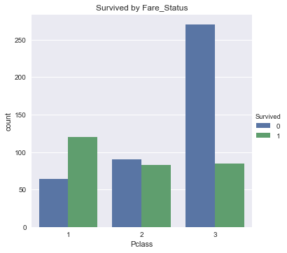

```python
sns.factorplot('Pclass', hue = "Survived", size = 5, data = clean_data, kind = 'count')
plt.title('Survived by Fare_Status');
```

```python
clean_data.groupby('Pclass')["Survived"].describe().T
```

| Pclass | 1 | 2 | 3 |
| --- | --- | --- | --- |
| count | 184.000000 | 173.000000 | 355.000000 |
| mean | 0.652174 | 0.479769 | 0.239437 |
| std | 0.477580 | 0.501041 | 0.427342 |
| min | 0.000000 | 0.000000 | 0.000000 |
| 25% | 0.000000 | 0.000000 | 0.000000 |
| 50% | 1.000000 | 0.000000 | 0.000000 |
| 75% | 1.000000 | 1.000000 | 0.000000 |
| max | 1.000000 | 1.000000 | 1.000000 |

As seen from factorplot, ticket class is related with survival rates. The higher ticket class (Class-1 is higher,Class-3 is lower), the higher survival chance.

Survival rates of Class-1,Class-2 and Class-3 tickets are 65.22%, 47.98% and 23.94% respectively.

We can also look at survival rates group by Fare_Status and Ticket Fare together:

```python
clean_data.groupby(['Fare_Status',"Pclass"])["Survived"].describe().T
```

| Fare_Status Pclass | Expensive 1 | Expensive 2 | Expensive 3 | Normal 1 | Normal 2 | Normal 3 | Outlier 1 |
| --- | --- | --- | --- | --- | --- | --- | --- |
| count | 80.000000 | 23.000000 | 31.000000 | 37.000000 | 150.000000 | 324.000000 | 67.000000 |
| mean | 0.625000 | 0.521739 | 0.193548 | 0.486486 | 0.473333 | 0.243827 | 0.776119 |
| std | 0.487177 | 0.510754 | 0.401610 | 0.506712 | 0.500961 | 0.430054 | 0.419989 |
| min | 0.000000 | 0.000000 | 0.000000 | 0.000000 | 0.000000 | 0.000000 | 0.000000 |
| 25% | 0.000000 | 0.000000 | 0.000000 | 0.000000 | 0.000000 | 0.000000 | 1.000000 |
| 50% | 1.000000 | 1.000000 | 0.000000 | 0.000000 | 0.000000 | 0.000000 | 1.000000 |
| 75% | 1.000000 | 1.000000 | 0.000000 | 1.000000 | 1.000000 | 0.000000 | 1.000000 |
| max | 1.000000 | 1.000000 | 1.000000 | 1.000000 | 1.000000 | 1.000000 | 1.000000 |

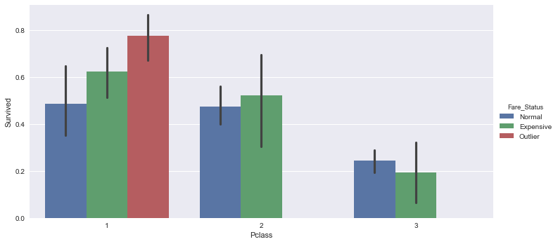

```python
sns.factorplot(x="Pclass", y="Survived", hue="Fare_Status",data=clean_data, kind="bar", size=5, aspect=2);
```

It is seen difference for Pclass1 and PClass2 passengers whether they paid expensive or normal rate. We need to check that they are statistically different.

Null hypothesis of Mann Whitney U test is both sample are same. If there is statistically difference, p-value should be less than 0.05.

```python
exp_class1 = clean_data[(clean_data['Pclass']==1) & (clean_data['Fare_Status']=="Expensive")].Survived
norm_class1 = clean_data[(clean_data['Pclass']==1) & (clean_data['Fare_Status']=="Normal")].Survived
```

```python
stats.mannwhitneyu(exp_class1,norm_class1, alternative="two-sided") # alternatives: 'less', 'two-sided','greater'
```

```
MannwhitneyuResult(statistic=1685.0, pvalue=0.16071676824049996)
```

According to test result, Expensive and Normal Rate of Fare statistically do not create difference for Class-1 passengers.

```python
exp_class2 = clean_data[(clean_data['Pclass']==2) & (clean_data['Fare_Status']=="Expensive")].Survived
norm_class2 = clean_data[(clean_data['Pclass']==2) & (clean_data['Fare_Status']=="Normal")].Survived
```

```python
stats.mannwhitneyu(exp_class2,norm_class2, alternative="two-sided")
```

```
MannwhitneyuResult(statistic=1808.5, pvalue=0.66803451018574633)
```

According to test result, Expensive or Normal Rate of Fare statistically do not create difference for Class-2 passengers.

**Answer for Question-2:**

Fare and Ticket class could be important factor to survive. Maybe it was related with priority to transfer to boats and location, but result is tend to passenger with expensive tickets were more likely to survive disaster.

Let's organize "Sex" column by defining passengers less than 12 years old as a child.

```python
def to_child(passenger):
    age,sex = passenger
    if age <= 12:
        return 'child'
    else:
        return sex

clean_data['Sex'] = clean_data[['Age','Sex']].apply(to_child,axis=1)
```

```python
clean_data.tail()
```

|  | PassengerId | Survived | Pclass | Name | Sex | Age | SibSp | Parch | Ticket | Fare | Embarked | Fare_Status |
| --- | --- | --- | --- | --- | --- | --- | --- | --- | --- | --- | --- | --- |
| 885 | 886 | 0 | 3 | Rice, Mrs. William (Margaret Norton) | female | 39.0 | 0 | 5 | 382652 | 29.125 | Q | Normal |
| 886 | 887 | 0 | 2 | Montvila, Rev. Juozas | male | 27.0 | 0 | 0 | 211536 | 13.000 | S | Normal |
| 887 | 888 | 1 | 1 | Graham, Miss. Margaret Edith | female | 19.0 | 0 | 0 | 112053 | 30.000 | S | Normal |
| 889 | 890 | 1 | 1 | Behr, Mr. Karl Howell | male | 26.0 | 0 | 0 | 111369 | 30.000 | C | Normal |
| 890 | 891 | 0 | 3 | Dooley, Mr. Patrick | male | 32.0 | 0 | 0 | 370376 | 7.750 | Q | Normal |

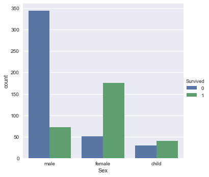

```python
sns.factorplot('Sex', hue = "Survived", size = 5, data = clean_data, kind = 'count')
```

In that structure, we can observe difference for females but not obvious for children.

Ticket class difference may affect this distribution. So we can group by ticket class and sex to observe:

```python
clean_data.groupby(['Sex',"Pclass"])["Survived"].describe().T
```

| Sex Pclass | child 1 | child 2 | child 3 | female 1 | female 2 | female 3 | male 1 | male 2 | male 3 |
| --- | --- | --- | --- | --- | --- | --- | --- | --- | --- |
| count | 4.00 | 17.0 | 48.000000 | 82.000000 | 66.000000 | 79.000000 | 98.000000 | 90.000000 | 228.000000 |
| mean | 0.75 | 1.0 | 0.416667 | 0.975610 | 0.909091 | 0.455696 | 0.377551 | 0.066667 | 0.127193 |
| std | 0.50 | 0.0 | 0.498224 | 0.155207 | 0.289683 | 0.501216 | 0.487267 | 0.250841 | 0.333922 |
| min | 0.00 | 1.0 | 0.000000 | 0.000000 | 0.000000 | 0.000000 | 0.000000 | 0.000000 | 0.000000 |
| 25% | 0.75 | 1.0 | 0.000000 | 1.000000 | 1.000000 | 0.000000 | 0.000000 | 0.000000 | 0.000000 |
| 50% | 1.00 | 1.0 | 0.000000 | 1.000000 | 1.000000 | 0.000000 | 0.000000 | 0.000000 | 0.000000 |
| 75% | 1.00 | 1.0 | 1.000000 | 1.000000 | 1.000000 | 1.000000 | 1.000000 | 0.000000 | 0.000000 |
| max | 1.00 | 1.0 | 1.000000 | 1.000000 | 1.000000 | 1.000000 | 1.000000 | 1.000000 | 1.000000 |

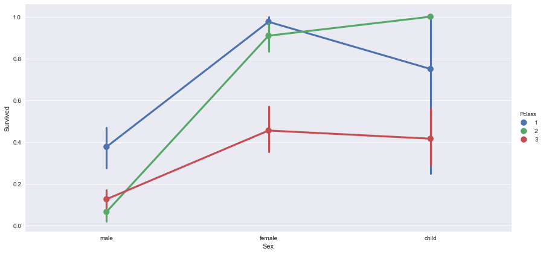

```python
sns.factorplot(x="Sex", y="Survived", hue="Pclass", data=clean_data, size=6, aspect=2);
```

**Answer for Question-3:**

Ladies and children may had priority to be placed boats on that day. Factorplot helps us to observe easily.

Ladies and children are more likely to survive, especially with class 1 and 2 tickets.

To answer 4th question, we will create new column as "Family_Size" by summing siblings-spouses and parents-child:

```python
clean_data["Family_Size"] = clean_data["SibSp"]+clean_data["Parch"]
```

```python
clean_data.head()
```

|  | PassengerId | Survived | Pclass | Name | Sex | Age | SibSp | Parch | Ticket | Fare | Embarked | Fare_Status | Family_Size |
| --- | --- | --- | --- | --- | --- | --- | --- | --- | --- | --- | --- | --- | --- |
| 0 | 1 | 0 | 3 | Braund, Mr. Owen Harris | male | 22.0 | 1 | 0 | A/5 21171 | 7.2500 | S | Normal | 1 |
| 1 | 2 | 1 | 1 | Cumings, Mrs. John Bradley (Florence Briggs Th... | female | 38.0 | 1 | 0 | PC 17599 | 71.2833 | C | Expensive | 1 |
| 2 | 3 | 1 | 3 | Heikkinen, Miss. Laina | female | 26.0 | 0 | 0 | STON/O2. 3101282 | 7.9250 | S | Normal | 0 |
| 3 | 4 | 1 | 1 | Futrelle, Mrs. Jacques Heath (Lily May Peel) | female | 35.0 | 1 | 0 | 113803 | 53.1000 | S | Expensive | 1 |
| 4 | 5 | 0 | 3 | Allen, Mr. William Henry | male | 35.0 | 0 | 0 | 373450 | 8.0500 | S | Normal | 0 |

We can obtain survival rate of different family sizes by using groupby and describe:

```python
clean_data.groupby(['Family_Size'])["Survived"].describe().T
```

| Family_Size | 0 | 1 | 2 | 3 | 4 | 5 | 6 | 7 |
| --- | --- | --- | --- | --- | --- | --- | --- | --- |
| count | 402.000000 | 139.000000 | 93.000000 | 27.000000 | 11.000000 | 22.000000 | 12.000000 | 6.0 |
| mean | 0.318408 | 0.546763 | 0.569892 | 0.777778 | 0.272727 | 0.136364 | 0.333333 | 0.0 |
| std | 0.466439 | 0.499609 | 0.497774 | 0.423659 | 0.467099 | 0.351250 | 0.492366 | 0.0 |
| min | 0.000000 | 0.000000 | 0.000000 | 0.000000 | 0.000000 | 0.000000 | 0.000000 | 0.0 |
| 25% | 0.000000 | 0.000000 | 0.000000 | 1.000000 | 0.000000 | 0.000000 | 0.000000 | 0.0 |
| 50% | 0.000000 | 1.000000 | 1.000000 | 1.000000 | 0.000000 | 0.000000 | 0.000000 | 0.0 |
| 75% | 1.000000 | 1.000000 | 1.000000 | 1.000000 | 0.500000 | 0.000000 | 1.000000 | 0.0 |
| max | 1.000000 | 1.000000 | 1.000000 | 1.000000 | 1.000000 | 1.000000 | 1.000000 | 0.0 |

According to this result, most survival rate is 77.78 % with Family Size 3. However sample size is small. Continue to investigation by kernel density estimate:

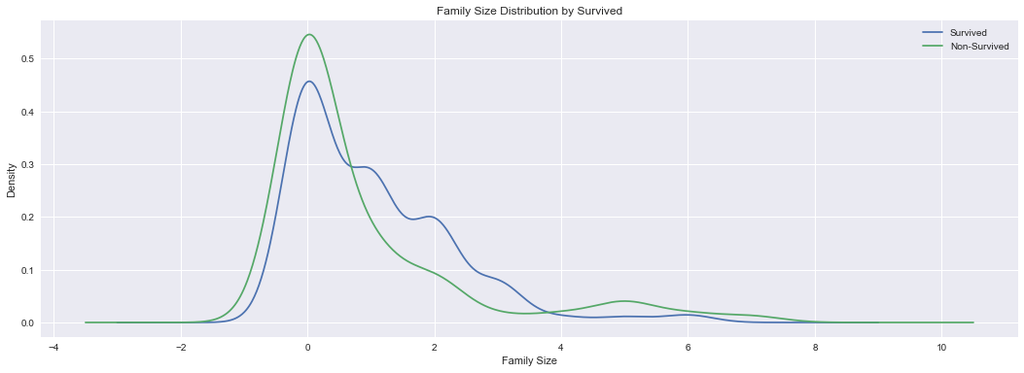

```python
clean_data.Family_Size[clean_data.Survived == 1].plot(kind='kde', figsize=(18,6))
clean_data.Family_Size[clean_data.Survived == 0].plot(kind='kde', figsize=(18,6))
plt.title("Family Size Distribution by Survived")
plt.xlabel("Family Size")
plt.legend(('Survived','Non-Survived'),loc='best')
plt.grid(b=True)
```

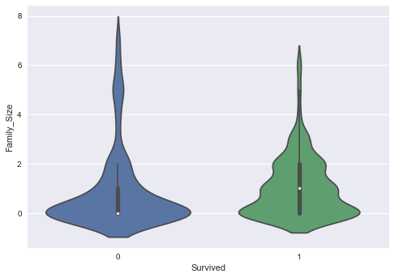

```python
sns.violinplot(data = clean_data, x = 'Survived', y = 'Family_Size');
```

Due to the smaller sample sizes, comparing of Family Sizes does not provide us significant information. So we can aggregate Family Sizes with "1"(With family) and "0"(Without family) as two main category.

```python
def to_family(passenger):
    if passenger>0:
        return 1
    else:
        return 0

clean_data['Family'] = clean_data["Family_Size"].apply(to_family)
```

```python
clean_data.tail()
```

|  | PassengerId | Survived | Pclass | Name | Sex | Age | SibSp | Parch | Ticket | Fare | Embarked | Fare_Status | Family_Size | Family |
| --- | --- | --- | --- | --- | --- | --- | --- | --- | --- | --- | --- | --- | --- | --- |
| 885 | 886 | 0 | 3 | Rice, Mrs. William (Margaret Norton) | female | 39.0 | 0 | 5 | 382652 | 29.125 | Q | Normal | 5 | 1 |
| 886 | 887 | 0 | 2 | Montvila, Rev. Juozas | male | 27.0 | 0 | 0 | 211536 | 13.000 | S | Normal | 0 | 0 |
| 887 | 888 | 1 | 1 | Graham, Miss. Margaret Edith | female | 19.0 | 0 | 0 | 112053 | 30.000 | S | Normal | 0 | 0 |
| 889 | 890 | 1 | 1 | Behr, Mr. Karl Howell | male | 26.0 | 0 | 0 | 111369 | 30.000 | C | Normal | 0 | 0 |
| 890 | 891 | 0 | 3 | Dooley, Mr. Patrick | male | 32.0 | 0 | 0 | 370376 | 7.750 | Q | Normal | 0 | 0 |

We can obtain survival rate of passengers with or without family members by using groupby and describe:

```python
clean_data.groupby(['Family'])["Survived"].describe().T
```

| Family | 0 | 1 |
| --- | --- | --- |
| count | 402.000000 | 310.000000 |
| mean | 0.318408 | 0.516129 |
| std | 0.466439 | 0.500548 |
| min | 0.000000 | 0.000000 |
| 25% | 0.000000 | 0.000000 |
| 50% | 0.000000 | 1.000000 |
| 75% | 1.000000 | 1.000000 |
| max | 1.000000 | 1.000000 |

According to result, 51.61 % of passengers with family member survived from disaster while 31.84 % of passengers without family member survived.

Also check with Mann Whitney U test:

```python
without_family = clean_data[clean_data['Family']==0].Survived
with_family = clean_data[clean_data['Family']==1].Survived
```

```python
stats.mannwhitneyu(without_family,with_family, alternative="two-sided")
```

```
MannwhitneyuResult(statistic=49990.0, pvalue=1.0050981924035183e-07)
```

According to test result, null hypothesis will change to alternative.

Statistically there is difference between travel with at least one family member and without any family member.

We can also observe interaction with Family and Pclass on Survival rate:

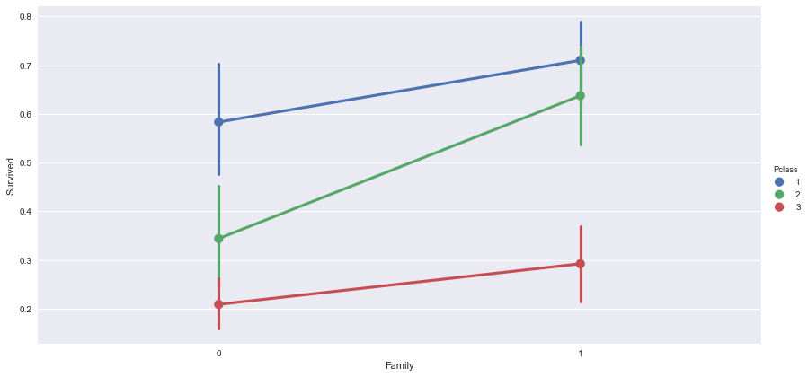

```python
sns.factorplot(x="Family", y="Survived", hue="Pclass", data=clean_data, size=6, aspect=2);
```

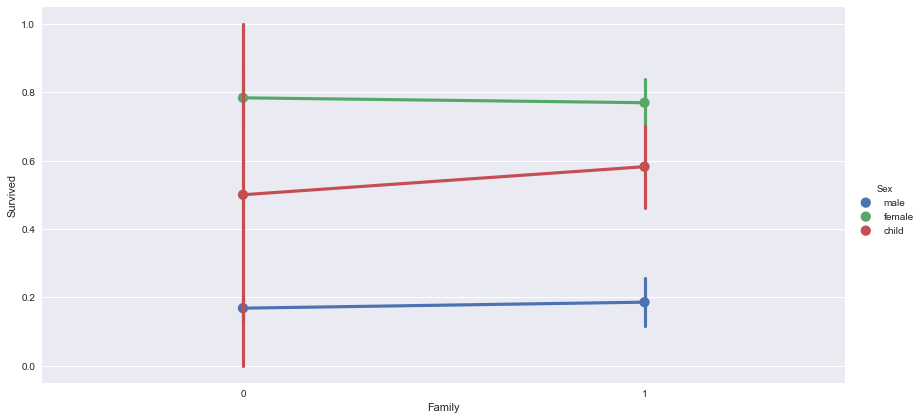

```python
sns.factorplot(x="Family", y="Survived", hue="Sex", data=clean_data, size=6, aspect=2);
```

**Answer for Question-4:**

Passengers who travelled with any family member were more likely to rescue from Titanic disaster than passengers travelled without any family member.

## Conclusion

According to analysis,tests and visulizations; we found these tentative results:

- Age is not important factor solely.
- Fare and Ticket class could be important factor to survive.
- Ladies and children are more likely to survive.
- Passengers who travelled with any family member were more likely to rescue.